# Лабораторная работа 5. Основы анализа данных NumPy и Matplotlib.

# Часть 1. NumPy

При решении научных задач с помощью численных методов зачастую приходится иметь дело с большими массивами данных в виде массивов и матриц. Стандартные средства Python (например, использование списков для хранения данных и прямой перебор элементов с помощью циклов) плохо подходят для таких задач, так как будут работать крайне медленно, в отличие от программ на компилируемых языках (Fortran, С). Пакет NumPy (http://www.numpy.org/) — это основной пакет, исполь¬зуемый в научных вычислениях в Python. NumPy предназначен для эф¬фективной работы с многомерными массивами, в том числе для эффек¬тивного применения математических операций к массивам и матрицам и их модификации без прямого перечисления элементов массивов. Поми¬мо этого NumPy обладает и другими возможностями — линейная алгеб¬ра, удобный ввод/вывод в файлы, моделирование случайных величин, быстрое преобразование Фурье, объединение программ на Fortran и С и другое (подробнее см. оф. сайт), поэтому важно изучить возможно¬сти данной библиотеки как можно лучше.

1. Внимательно изучите следующий урок по NumPy: http://scipy.github.io/old-wiki/pages/Tentative_NumPy_Tutorial.
2. Изучите официальное руководство пользователя https://docs.scipy.org/doc/numpy/user/.
3. Внимательно изучите Reference Guide (полное описание всех функ¬ций) https://docs.scipy.org/doc/numpy/reference/, именно в нем перечислены все возможности NumPy, этой ссылкой придется регу¬лярно пользоваться.

Выполните следующие задания (их много, но каждое занимает одну или несколько строк) средствами NumPy (и без использования циклов!)

Импортируйте пакет numpy под именем nр

```python
import numpy as np
```

Импортируйте пакет numpy под именем пр

```python
import numpy as np
```

Создайте вектор из 10 элементов, заполненный 0, пятый эле-мент которого равен 1.

```python
vector = np.zeros(10)
vector[4] = 1
print(vector)
```

```
[0. 0. 0. 0. 1. 0. 0. 0. 0. 0.]
```

Создайте вектор из 10 элементов, заполненный 0, пятый эле-мент которого равен 1.

```python
vector = np.zeros(10)
vector[4] = 1
print(vector)
```

```
[0. 0. 0. 0. 1. 0. 0. 0. 0. 0.]
```

Создайте матрицу 3 на 3 со значениями от 0 до 8.

```python
matrix = np.linspace(0,8,9).reshape(3,3)
print(matrix)
```

```
[[0. 1. 2.]
 [3. 4. 5.]
 [6. 7. 8.]]
```

Найдите индексы ненулевых элементов вектора [1,2,0,0,4,0].

```python
indexes = np.nonzero([1,2,0,0,4,0])
print(indexes)
```

```
(array([0, 1, 4], dtype=int32),)
```

Объявите единичную матрицу размером 3 на 3.

```python
matr = np.eye(3)
print(matr)
```

```
[[1. 0. 0.]
 [0. 1. 0.]
 [0. 0. 1.]]
```

Создайте массив 10x10x10 из случайных чисел.

```python
np.empty((10,10,10))
```

[output not shown]

[output cut: 354 more lines]

[output not shown]

```python
mat = np.tile(np.array([0,1]), (4,4))
print (mat)
```

```
[[0 1 0 1 0 1 0 1]
 [0 1 0 1 0 1 0 1]
 [0 1 0 1 0 1 0 1]
 [0 1 0 1 0 1 0 1]]
```

Найдите произведение матриц 5x3 на 3x2 (см. линейную ал-гебру) .

```python
mat = np.dot(np.linspace(0,14,15).reshape(5,3),np.linspace(0,5,6).reshape(3,2))
print(mat)
```

```
[[ 10.  13.]
 [ 28.  40.]
 [ 46.  67.]
 [ 64.  94.]
 [ 82. 121.]]
```

Создайте матрицу, в каждом ряду которой стоят числа от 0 до 8 (используйте сложение матрицы с вектором).

```python
print("Перове задание:")
mat = np.zeros((9,9))+np.linspace(0,8,9)
print (mat)


print()
print("Второе задание:")
#Второе задание снизу:
numbers = np.empty((1000))
print(numbers)
print("Среднее:")
print(numbers.mean())
#Беретсу рандомные цифры с системы(мусор) и гдето видно затесалось нехорошое значение, реализуем через обычный рандом:
print()
print("Второе задание V2:")
numbers2 = np.random.random(1000)*10
print(numbers2)
print("Среднее:")
print(numbers2.mean())
```

[output not shown]

[output cut: 463 more lines]

[output not shown]

## Часть 2. Matplotlib

Matplotlib (http://matplotlib.org/index.html) — это библиотека для создания графиков в Python. Matplotlib позволяет строить графики любой сложности типографского качества, которые можно вставить в статью. Подробнее о возможностях см. http://matplotlib.org/users/ intro.html. Matplotlib — большой и сложный инструмент, но на прак¬тике в научных вычислениях часто пользуются частью библиотеки matplotlib .pyplot, которая имитирует построение графиков в стиле MATLAB. В качестве до¬статочно полного введения можно прочитать http://matplotlib.org/users/index.html.

На практике бывает очень трудно помнить все возможности Matplotlib, поэтому часто используют галереи готовых примеров, а потом модифи-цируют их под свои нужды. Примеры таких подборок можно найти по следующим ссылкам: • http://matplotlib.org/gallery.html • http://matplotlib.org/examples/index.html • http://wiki.scipy.org/Cookbook/Matplotlib/

Еще материалы.

1. Введение http://matplotlib.org/users/pyplot_tutorial.html
2. Введение 2 http://www.loria.fr/~rougier/teaching/matplotlib/. Изучите, как создавать графики разных типов http://www.loria. fr/~rougier/teaching/matplotlib/#other-types-of-plots.
3. Использование текста в подписях и т.д. http://matplotlib.org/ users/text_intro.html.
4. Использование математического текста http: //matplotlib. org/users/ mathtext.html.
5. Создание легенды http://matplotlib.org/users/legend_guide.html.
6. Интерактивное использование Matplotlib http: //matplotlib. org/ users/shell .html (этот пример можно использовать не только в командной строке, но и в коде для наблюдения за изменением гра¬фиков в ходе выполнения программы).

Постройте поточечный график функции. Сгенерируйте два массива для этого. Один со значениями по возрастанию (для X), второй со случайными значениями (для Y).

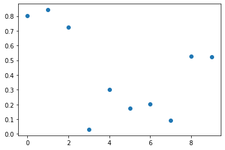

```python
import math
import matplotlib.pyplot as mplt
%matplotlib inline

x = np.arange(10)
y = np.random.random(10)

print(mplt.plot(x, y, 'o'))
```

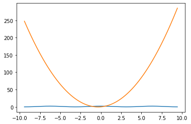

```python
x = np.linspace(-3*np.pi, 3*np.pi, 200)
T = np.cos(x) + 1
P = 2*x + 3*x*x
fig, ax = mplt.subplots()
ax.plot(x, T)
ax.plot(x, P)
mplt.show()
```

К графику добавьте: обозначение оси абсцисс, обозначение оси ординат, название графика, вставка легенды (текста в label).

[figure not shown]

```python
x = np.linspace(-3*np.pi, 3*np.pi, 200)
T = np.cos(x) + 1
P = 2*x + 3*x*x
fig, ax = mplt.subplots()
ax.plot(x, T, label = "sin(x)")
ax.plot(x, P, label = "2*x + 4*x*x")
mplt.title("T(x)P(x)")
mplt.xlabel("Ox")
mplt.ylabel("Oy")
ax.legend()
```

Измените цвет графика на Ваш любимый.

[figure not shown]

```python
x = np.linspace(-3*np.pi, 3*np.pi, 200)
T = np.cos(x) + 1
P = 2*x + 3*x*x
fig, ax = mplt.subplots()
ax.plot(x, T, label = "sin(x)", color="blue")
ax.plot(x, P, label = "2*x + 4*x*x", color="red")
mplt.title("T(x)P(x)")
mplt.xlabel("Ox")
mplt.ylabel("Oy")
ax.legend()
```

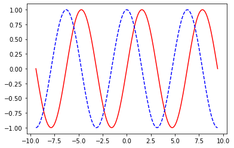

```python
x = np.linspace(-3*np.pi, 3*np.pi, 200)
T = np.sin(x)
P = np.cos(x)
fig, ax = mplt.subplots()
ax.plot(x, T, color = "red", linestyle = "-")
ax.plot(x, P, color = "blue", linestyle = "--")
```

Постройте теже графики, только для первого добавьте маркеры из красных треугольников, для второго синие круглые маркеры.

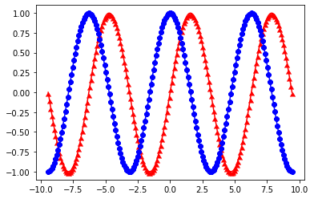

```python
x = np.linspace(-3*np.pi, 3*np.pi, 200)
T = np.sin(x)
P = np.cos(x)
fig, ax = mplt.subplots()
ax.plot(x, T, color = "red", marker = 6)
ax.plot(x, P, color = "blue", marker = "8")
fig.savefig('graph')
```

# Часть 3. OpenCV

Прочитайте картинку используя opencv

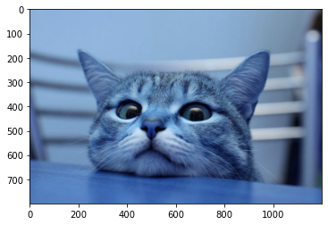

```python
import cv2
import matplotlib.pyplot as plt
img = cv2.imread('img1.jpg')
mplt.imshow(img)
```

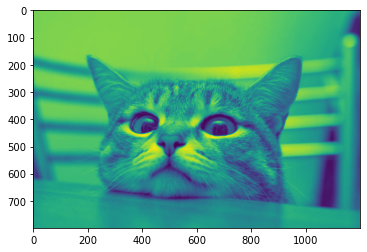

```python
ImgGray = cv2.cvtColor(img, cv2.COLOR_BGR2GRAY)
plt.imshow(ImgGray)
```

Измените размер на 300x300

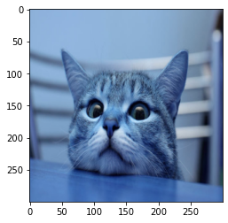

```python
imag = cv2.resize((img), (300, 300))
plt.imshow(imag)
```

Разбейте ее на 2 картинки. Сохраните.

```python
(h, w) = imag.shape[:2]
left = imag[:h, :w//2]
right = imag[:h, w//2:]
cv2.imwrite('imgLeft.png', left)
cv2.imwrite('imgRight.png', right)
```

```
True
```

Прочитайте 2 картинки и склейте.

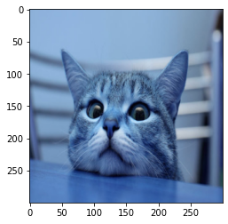

```python
img1 = cv2.imread('imgLeft.png',1)
img2 = cv2.imread('imgRight.png',1)
vis = np.concatenate((img1, img2), axis=1)
plt.imshow(vis)
```